### Use national river datasets to estimate regional hydraulic geometry relationships

#### *Generated on 2020-12-08*

There are many instances of stream and river segments where we don’t have field measurements of channel geometry, but it’s desirable to be able to estimate width and depth (either mean annual conditions and/or bankfull conditions). Width, depth, and velocity are commonly estimated using hydraulic geometry coefficients that vary as a function of discharge. River width, depth, and velocity often vary with discharge as simple power functions, as shown in the fundamental paper by Leopold and Maddock (1953), where:

$v = k * Q^m$

$w = a * Q^b$

$d = c * Q^d$

Here, *k*, *a*, and *c* are proportionality constants, and *m*, *b*, and *f* are the power law exponents. Since $Q = v * w *d$, then  
$m + b+ f \approx 1$ and  
$k*a*c \approx 1$.

Values of the power law exponents reported by Leopold and Maddock (1953) were *b* = 0.26, *f* = 0.40, and *m* = 0.34, respectively, when considering a particular river cross-section over a range of flow conditions (*at-a-site relationships*). Similar power law relationships are observed when analyzing hydraulic geometry in cross-sections when moving in the downstream direction (*downstream relationships*). Mean values of the exponents in the downstream direction were equal to *b* = 0.5, *f* = 0.4, and *m* = 0.1. The implication of these values is that width, for example, varies more in the downstream direction than at a given river cross-section.

Hydraulic geometry analyses based on summaries of field measurements of channel geometry and reported discharge have expanded in scope to include streams and rivers spanning river sizes and geographic regions (e.g. [Raymond et al. 2012](https://aslopubs.onlinelibrary.wiley.com/doi/full/10.1215/21573689-1597669)). However, the relationships reported by Raymond et al. (2012) are generalized across all observed streams and rivers in their dataset, when there may be reason to expect differences in hydraulic geometry scaling across regions, for example.

**My objective here is to conduct a similar hydraulic geometry analysis for individual HUC2 watersheds (“hydroregions”) within the contiguous United States to provide region-specific empirical equations used for estimating river width and depth.**

We will use field-based measures of baseflow and bankfull widths and depths by the U.S. Environmental Protection Agency as part of the Wadeable Streams Assessment and the National Streams and Rivers Assessment. If we assume that $Q \propto A$, we can develop empirical relationships between width, depth, and upstream watershed area with the help of the NHDPlus dataset.

**Empirical Datasets:**  
[EPA NRSA homepage](https://www.epa.gov/national-aquatic-resource-surveys/nrsa)  
- Wadeable Streams Assessment (2004-2005)  
- National Streams and Rivers Assessment (2008-2009)

**Analysis steps:**  
- Download field observations from EPA datasets (WSA and NRSA)  
- Join field observations to nearest [NHDPlusV2 flowline segment](https://www.epa.gov/waterdata/nhdplus-national-hydrography-dataset-plus)  
- Estimate upstream area for each sample location based on the total area at the bottom of the corresponding NHDPlus flowline and the location of the field sample point along that NHDPlus flowline (i.e., the proportional reach length).  
- For each HUC2 region, conduct standardized major axis regression (SMA) to develop watershed area-width relationships.

**Plot national-scale relationship between upstream watershed area and width:**

**Estimate width based on national-scale relationship between upstream watershed area and width:**

```r
## Standardized major axis regression: national-scale relationship

# Estimate coefficients of standardizd major axis regression (SMA):
  sma.national <- sma(log10(dat_JoinNHD2$WettedWidth_m) ~ log10(dat_JoinNHD2$TOTDASQKM), robust=T)

  # Apply coefficients to estimate width given national-scale relationship:
  dat_JoinNHD2$EstWidth_NatlSMA <- 10^((log10(dat_JoinNHD2$TOTDASQKM) * sma.national$coef[[1]][2,1])+sma.national$coef[[1]][1,1])
```

[figure not shown]

**Estimate width based on regional-scale relationships between upstream watershed area and width (by HUC02 regions):**

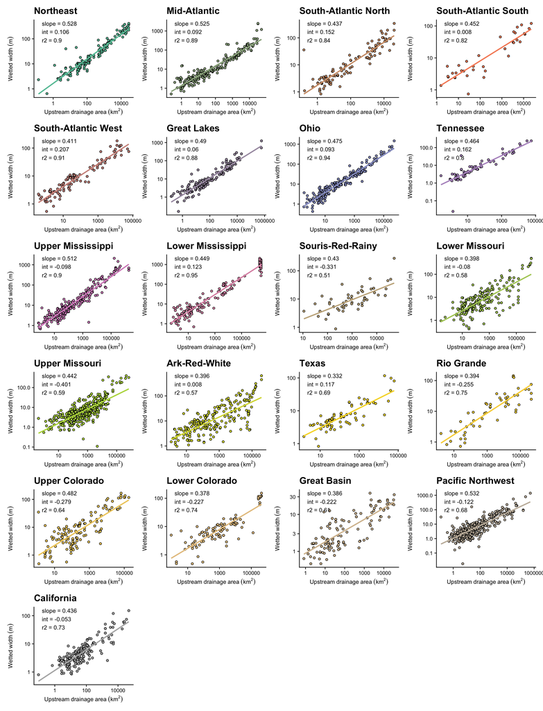

Drainage Area - width relationships for U.S. HUC02 regions

| HUC02 | name | slope | intercept | slope_lowCI | slope_upperCI | int_lowCI | int_upperCI |
| --- | --- | --- | --- | --- | --- | --- | --- |
| 01 | Northeast | 0.528 | 0.106 | 0.508 | 0.547 | 0.054 | 0.159 |
| 02 | Mid-Atlantic | 0.525 | 0.092 | 0.506 | 0.544 | 0.050 | 0.134 |
| 03N | South-Atlantic North | 0.437 | 0.152 | 0.413 | 0.463 | 0.086 | 0.218 |
| 03S | South-Atlantic South | 0.452 | 0.008 | 0.401 | 0.509 | -0.147 | 0.162 |
| 03W | South-Atlantic West | 0.411 | 0.207 | 0.388 | 0.436 | 0.156 | 0.258 |
| 04 | Great Lakes | 0.490 | 0.060 | 0.466 | 0.514 | 0.005 | 0.116 |
| 05 | Ohio | 0.475 | 0.093 | 0.461 | 0.489 | 0.056 | 0.129 |
| 06 | Tennessee | 0.464 | 0.162 | 0.434 | 0.496 | 0.101 | 0.224 |
| 07 | Upper Mississippi | 0.512 | -0.098 | 0.492 | 0.532 | -0.150 | -0.045 |
| 08 | Lower Mississippi | 0.449 | 0.123 | 0.438 | 0.459 | 0.073 | 0.172 |
| 09 | Souris-Red-Rainy | 0.430 | -0.331 | 0.351 | 0.526 | -0.605 | -0.058 |
| 10L | Lower Missouri | 0.398 | -0.080 | 0.360 | 0.440 | -0.183 | 0.024 |
| 10U | Upper Missouri | 0.442 | -0.401 | 0.413 | 0.473 | -0.489 | -0.313 |
| 11 | Ark-Red-White | 0.396 | 0.008 | 0.365 | 0.429 | -0.091 | 0.107 |
| 12 | Texas | 0.332 | 0.117 | 0.288 | 0.383 | 0.007 | 0.226 |
| 13 | Rio Grande | 0.394 | -0.255 | 0.342 | 0.453 | -0.456 | -0.055 |
| 14 | Upper Colorado | 0.482 | -0.279 | 0.435 | 0.534 | -0.413 | -0.145 |
| 15 | Lower Colorado | 0.378 | -0.227 | 0.341 | 0.419 | -0.350 | -0.103 |
| 16 | Great Basin | 0.386 | -0.222 | 0.350 | 0.426 | -0.323 | -0.121 |
| 17 | Pacific Northwest | 0.532 | -0.122 | 0.501 | 0.564 | -0.181 | -0.064 |
| 18 | California | 0.436 | -0.053 | 0.398 | 0.479 | -0.128 | 0.021 |